# Exploratory Analysis of Macro-Economic Aggregates of India from 2004-21

### First we need to import some libraries which will be helpful in performing Exploratory Data Analysis

```python
import numpy as np
import pandas as pd
import matplotlib.pyplot as plt
import seaborn as sns
```

```python
pd.set_option('display.max_rows', 65)
pd.set_option('display.max_columns', 30)
pd.set_option('display.width', 1000)
pd.set_option('display.float_format', lambda x: '%.5f' % x)
```

```python
df_1 = pd.read_excel('Book2.xlsx') # Creating a dataframe to work with, from the excel file
df_1
```

|  | Year | GVA at Basic Prices | Consumption of Fixed Capital | NVA at Basic Prices | Indirect Taxes less Subsidies | GDP at Market Prices | NDP at Market Prices | Net Factor Income from Abroad | GNP at Basic Prices | NNP at Basic Prices | GNP at Market Prices | NNP at Market Prices | Gross Capital Formation | Net Capital Formation | Per Capita GNI | Per Capita GDP | Per Capita NNI | Per Capita PFCE | Net National Disposable Income | per capita GNI at factor cost | Per Capita GNDI | Net Savings | Gross Savings | Gross National Disposable Income | Other current transfers (net) from ROW | rate of gross domestic saving* | Population(in million) |
| --- | --- | --- | --- | --- | --- | --- | --- | --- | --- | --- | --- | --- | --- | --- | --- | --- | --- | --- | --- | --- | --- | --- | --- | --- | --- | --- | --- |
| 0 | 2004-05 | 5092503.00000 | 475848 | 4616655 | 387877.00000 | 5480380.00000 | 5004532 | -37442 | 5055061 | 4579213 | 5442938.00000 | 4967090.00000 | 1629848 | 1154000 | 29054.00000 | 50325.00000 | 45611.00000 | 29646.00000 | - | 49981 | - | - | - | - | - | - | - |
| 1 | 2005-06 | 5514228.00000 | 521312 | 4992916 | 400386.00000 | 5914614.00000 | 5393302 | -41678 | 5472550 | 4951238 | 5872936.00000 | 5351624.00000 | 1943997 | 1422685 | 32604.00000 | 53478.00000 | 48387.00000 | 31367.00000 | - | 53101 | - | - | - | - | - | - | - |
| 2 | 2006-07 | 5958367.00000 | 571823 | 5386544 | 433008.00000 | 6391375.00000 | 5819552 | -48986 | 5909381 | 5337558 | 6342389.00000 | 5770565.00000 | 2140999 | 1569176 | 37624.00000 | 56964.00000 | 51431.00000 | 32445.00000 | - | 56528 | - | - | - | - | - | - | - |
| 3 | 2007-08 | 6398295.00000 | 633675 | 5764620 | 482712.00000 | 6881007.00000 | 6247332 | -28267 | 6370028 | 5736353 | 6852740.00000 | 6219065.00000 | 2663579 | 2029904 | 42866.00000 | 60466.00000 | 54649.00000 | 34318.00000 | - | 60217 | - | - | - | - | - | - | - |
| 4 | 2008-09 | 6674215.00000 | 693547 | 5980668 | 419188.00000 | 7093403.00000 | 6399855 | -41212 | 6633003 | 5939456 | 7052191.00000 | 6358644.00000 | 2456984 | 1763437 | 47498.00000 | 61468.00000 | 55101.00000 | 35349.00000 | - | 61111 | - | - | - | - | - | - | - |
| 5 | 2009-10 | 7131836.00000 | 768601 | 6363235 | 519242.00000 | 7651078.00000 | 6882477 | -44759 | 7087077 | 6318476 | 7606319.00000 | 6837719.00000 | 2772552 | 2003951 | 54089.00000 | 65394.00000 | 58442.00000 | 36610.00000 | - | 65011 | - | - | - | - | - | - | - |
| 6 | 2010-11 | 7704514.00000 | 838432 | 6866082 | 596721.00000 | 8301235.00000 | 7462803 | -89419 | 7615095 | 6776663 | 8211816.00000 | 7373384.00000 | 3330444 | 2492012 | 63682.00000 | 69994.00000 | 62170.00000 | 38543.00000 | - | 69240 | - | - | - | - | - | - | - |
| 7 | 2011-12 | 8106945.99353 | 917174.94081 | 7189771.05272 | 629382.71784 | 8736328.81089 | 7819153.77056 | -76824 | 8030121.99353 | 7112947.05272 | 8659504.71137 | 7742329.77056 | 3403008.15161 | 2485833.21080 | 70979.54681 | 71609.25173 | 63461.71943 | 40249.56769 | - | - | - | - | - | - | - | - | - |
| 8 | 2012-13 | 8546275.45618 | 1010661.07525 | 7535614.27460 | 666741.31242 | 9213016.76860 | 8202355.58702 | -108354.46673 | 8437920.88311 | 7427259.80787 | 9104662.19554 | 8094001.12029 | 3639296.36941 | 2628635.29416 | 73721.96110 | 74599.32520 | 65538.47061 | 41935.95768 | - | - | - | - | - | - | - | - | - |
| 9 | 2013-14 | 9063648.61396 | 1100609.87304 | 7963038.79500 | 737721.20821 | 9801369.82218 | 8700760.00321 | -122342.85847 | 8941305.80958 | 7840695.93653 | 9679027.01779 | 8578417.14475 | 3448235.84073 | 2347625.96769 | 77370.31989 | 78348.28039 | 68572.47918 | 44423.09022 | - | - | - | - | - | - | - | - | - |
| 10 | 2014-15 | 9712132.79015 | 1178644.23797 | 8533488.55219 | 815541.00000 | 10527673.63442 | 9349029.39646 | -124686.54170 | 9587446.24846 | 8408802.01049 | 10402987.09273 | 9224342.85476 | 3659762.88113 | 2481118.64316 | 82107.23830 | 83091.34676 | 72804.60027 | 46666.58817 | - | - | - | - | - | - | - | - | - |
| 11 | 2015-16 | 10491870.34658 | 1270890.39824 | 9220979.94834 | 877623.00000 | 11369493.13596 | 10098602.73772 | -134922.08717 | 10356948.25941 | 9086057.86117 | 11234571.04879 | 9963680.65055 | 3917358.30319 | 2646467.90495 | 87564.85619 | 88616.47027 | 77659.24124 | 49738.25967 | - | - | - | - | - | - | - | - | - |
| 12 | 2016-17 | 11328284.62437 | 1381526.33373 | 9946758.29064 | 979909.00000 | 12308193.22327 | 10926666.88954 | -144574.67001 | 11183709.95436 | 9802183.62063 | 12163618.55326 | 10782092.21953 | 4300878.84148 | 2919352.50775 | 93638.32604 | 94751.29502 | 83003.01940 | 53119.59973 | - | - | - | - | - | - | - | 979908.59890 | - |
| 13 | 2017-18 | 12034170.51373 | 1489920.81578 | 10585661.87716 | 1110412.00000 | 13144582.14474 | 11654661.32896 | -145887.61070 | 11928560.33090 | 10439808.77947 | 12998694.53404 | 11508773.72000 | 4922971.90079 | 3433051.08501 | 98924.61594 | 100034.87173 | 87585.79694 | 55789.41009 | - | - | - | - | - | - | - | 1100746.87587 | - |
| 14 | 2018-19 | 12733797.76935 | 1614455.06220 | 11193752.70685 | 1259116.16693 | 13992913.93628 | 12378458.87408 | -152440.18988 | 12650769.93005 | 11041394.77649 | 13840473.74640 | 12226018.68000 | 5225982.16530 | 3611527.10310 | 104298.97322 | 105447.73125 | 92132.77079 | 59159.33609 | - | - | - | - | - | - | - | 1178297.82037 | - |
| 15 | 2019-20 | 13219475.58546 | 1732620.24371 | - | 1296482.07227 | 14515957.65773 | 12783337.41402 | -141704.39576 | - | - | 14374253.26197 | 12641633.01826 | 4954568.19841 | 3221947.95469 | 107190.55378 | 108247.26068 | 94270.19402 | 61593.61928 | - | - | - | - | - | - | - | - | 1341 |
| 16 | 2020-21 | 12585073.61803 | 1832274.91487 | - | 973399.78400 | 13558473.40203 | 11726198.48716 | -190194.68244 | - | - | 13368278.71959 | 11536003.80472 | 4269908.83383 | 2437633.91896 | 98628.53070 | 100031.74965 | 85110.36681 | 57279.30120 | - | - | - | - | - | - | - | - | - |
| 17 | 2021-22 | 13605474.00066 | - | - | 1130041.48982 | 14735515.49048 | - | - | - | - | 14500811.81350 | 12519975.66800 | - | - | 105954.62191 | 107669.55619 | 91481.03605 | 61215.35373 | - | - | - | - | - | - | - | - | - |

```python
df_1.info() # Checking the general info about the data
```

```
<class 'pandas.core.frame.DataFrame'>
RangeIndex: 18 entries, 0 to 17
Data columns (total 27 columns):
 #   Column                                  Non-Null Count  Dtype
---  ------                                  --------------  -----
 0   Year                                    18 non-null     object
 1   GVA at Basic Prices                     18 non-null     float64
 2   Consumption of Fixed Capital            18 non-null     object
 3   NVA at Basic Prices                     18 non-null     object
 4   Indirect Taxes less Subsidies           18 non-null     float64
 5   GDP at Market Prices                    18 non-null     float64
 6   NDP at Market Prices                    18 non-null     object
 7   Net Factor Income from Abroad           18 non-null     object
 8   GNP at Basic Prices                     18 non-null     object
 9   NNP at Basic Prices                     18 non-null     object
```

[output cut: 19 more lines]

### Data Preprocessing

- Since data for 2021-22, is not available for each column, we are neglecting that year in our study.

```python
df_2 = df_1.drop(labels = 17, axis = 0) # This will not alter the original dataframe
df_1
```

|  | Year | GVA at Basic Prices | Consumption of Fixed Capital | NVA at Basic Prices | Indirect Taxes less Subsidies | GDP at Market Prices | NDP at Market Prices | Net Factor Income from Abroad | GNP at Basic Prices | NNP at Basic Prices | GNP at Market Prices | NNP at Market Prices | Gross Capital Formation | Net Capital Formation | Per Capita GNI | Per Capita GDP | Per Capita NNI | Per Capita PFCE | Net National Disposable Income | per capita GNI at factor cost | Per Capita GNDI | Net Savings | Gross Savings | Gross National Disposable Income | Other current transfers (net) from ROW | rate of gross domestic saving* | Population(in million) |
| --- | --- | --- | --- | --- | --- | --- | --- | --- | --- | --- | --- | --- | --- | --- | --- | --- | --- | --- | --- | --- | --- | --- | --- | --- | --- | --- | --- |
| 0 | 2004-05 | 5092503.00000 | 475848 | 4616655 | 387877.00000 | 5480380.00000 | 5004532 | -37442 | 5055061 | 4579213 | 5442938.00000 | 4967090.00000 | 1629848 | 1154000 | 29054.00000 | 50325.00000 | 45611.00000 | 29646.00000 | - | 49981 | - | - | - | - | - | - | - |
| 1 | 2005-06 | 5514228.00000 | 521312 | 4992916 | 400386.00000 | 5914614.00000 | 5393302 | -41678 | 5472550 | 4951238 | 5872936.00000 | 5351624.00000 | 1943997 | 1422685 | 32604.00000 | 53478.00000 | 48387.00000 | 31367.00000 | - | 53101 | - | - | - | - | - | - | - |
| 2 | 2006-07 | 5958367.00000 | 571823 | 5386544 | 433008.00000 | 6391375.00000 | 5819552 | -48986 | 5909381 | 5337558 | 6342389.00000 | 5770565.00000 | 2140999 | 1569176 | 37624.00000 | 56964.00000 | 51431.00000 | 32445.00000 | - | 56528 | - | - | - | - | - | - | - |
| 3 | 2007-08 | 6398295.00000 | 633675 | 5764620 | 482712.00000 | 6881007.00000 | 6247332 | -28267 | 6370028 | 5736353 | 6852740.00000 | 6219065.00000 | 2663579 | 2029904 | 42866.00000 | 60466.00000 | 54649.00000 | 34318.00000 | - | 60217 | - | - | - | - | - | - | - |
| 4 | 2008-09 | 6674215.00000 | 693547 | 5980668 | 419188.00000 | 7093403.00000 | 6399855 | -41212 | 6633003 | 5939456 | 7052191.00000 | 6358644.00000 | 2456984 | 1763437 | 47498.00000 | 61468.00000 | 55101.00000 | 35349.00000 | - | 61111 | - | - | - | - | - | - | - |
| 5 | 2009-10 | 7131836.00000 | 768601 | 6363235 | 519242.00000 | 7651078.00000 | 6882477 | -44759 | 7087077 | 6318476 | 7606319.00000 | 6837719.00000 | 2772552 | 2003951 | 54089.00000 | 65394.00000 | 58442.00000 | 36610.00000 | - | 65011 | - | - | - | - | - | - | - |
| 6 | 2010-11 | 7704514.00000 | 838432 | 6866082 | 596721.00000 | 8301235.00000 | 7462803 | -89419 | 7615095 | 6776663 | 8211816.00000 | 7373384.00000 | 3330444 | 2492012 | 63682.00000 | 69994.00000 | 62170.00000 | 38543.00000 | - | 69240 | - | - | - | - | - | - | - |
| 7 | 2011-12 | 8106945.99353 | 917174.94081 | 7189771.05272 | 629382.71784 | 8736328.81089 | 7819153.77056 | -76824 | 8030121.99353 | 7112947.05272 | 8659504.71137 | 7742329.77056 | 3403008.15161 | 2485833.21080 | 70979.54681 | 71609.25173 | 63461.71943 | 40249.56769 | - | - | - | - | - | - | - | - | - |
| 8 | 2012-13 | 8546275.45618 | 1010661.07525 | 7535614.27460 | 666741.31242 | 9213016.76860 | 8202355.58702 | -108354.46673 | 8437920.88311 | 7427259.80787 | 9104662.19554 | 8094001.12029 | 3639296.36941 | 2628635.29416 | 73721.96110 | 74599.32520 | 65538.47061 | 41935.95768 | - | - | - | - | - | - | - | - | - |
| 9 | 2013-14 | 9063648.61396 | 1100609.87304 | 7963038.79500 | 737721.20821 | 9801369.82218 | 8700760.00321 | -122342.85847 | 8941305.80958 | 7840695.93653 | 9679027.01779 | 8578417.14475 | 3448235.84073 | 2347625.96769 | 77370.31989 | 78348.28039 | 68572.47918 | 44423.09022 | - | - | - | - | - | - | - | - | - |
| 10 | 2014-15 | 9712132.79015 | 1178644.23797 | 8533488.55219 | 815541.00000 | 10527673.63442 | 9349029.39646 | -124686.54170 | 9587446.24846 | 8408802.01049 | 10402987.09273 | 9224342.85476 | 3659762.88113 | 2481118.64316 | 82107.23830 | 83091.34676 | 72804.60027 | 46666.58817 | - | - | - | - | - | - | - | - | - |
| 11 | 2015-16 | 10491870.34658 | 1270890.39824 | 9220979.94834 | 877623.00000 | 11369493.13596 | 10098602.73772 | -134922.08717 | 10356948.25941 | 9086057.86117 | 11234571.04879 | 9963680.65055 | 3917358.30319 | 2646467.90495 | 87564.85619 | 88616.47027 | 77659.24124 | 49738.25967 | - | - | - | - | - | - | - | - | - |
| 12 | 2016-17 | 11328284.62437 | 1381526.33373 | 9946758.29064 | 979909.00000 | 12308193.22327 | 10926666.88954 | -144574.67001 | 11183709.95436 | 9802183.62063 | 12163618.55326 | 10782092.21953 | 4300878.84148 | 2919352.50775 | 93638.32604 | 94751.29502 | 83003.01940 | 53119.59973 | - | - | - | - | - | - | - | 979908.59890 | - |
| 13 | 2017-18 | 12034170.51373 | 1489920.81578 | 10585661.87716 | 1110412.00000 | 13144582.14474 | 11654661.32896 | -145887.61070 | 11928560.33090 | 10439808.77947 | 12998694.53404 | 11508773.72000 | 4922971.90079 | 3433051.08501 | 98924.61594 | 100034.87173 | 87585.79694 | 55789.41009 | - | - | - | - | - | - | - | 1100746.87587 | - |
| 14 | 2018-19 | 12733797.76935 | 1614455.06220 | 11193752.70685 | 1259116.16693 | 13992913.93628 | 12378458.87408 | -152440.18988 | 12650769.93005 | 11041394.77649 | 13840473.74640 | 12226018.68000 | 5225982.16530 | 3611527.10310 | 104298.97322 | 105447.73125 | 92132.77079 | 59159.33609 | - | - | - | - | - | - | - | 1178297.82037 | - |
| 15 | 2019-20 | 13219475.58546 | 1732620.24371 | - | 1296482.07227 | 14515957.65773 | 12783337.41402 | -141704.39576 | - | - | 14374253.26197 | 12641633.01826 | 4954568.19841 | 3221947.95469 | 107190.55378 | 108247.26068 | 94270.19402 | 61593.61928 | - | - | - | - | - | - | - | - | 1341 |
| 16 | 2020-21 | 12585073.61803 | 1832274.91487 | - | 973399.78400 | 13558473.40203 | 11726198.48716 | -190194.68244 | - | - | 13368278.71959 | 11536003.80472 | 4269908.83383 | 2437633.91896 | 98628.53070 | 100031.74965 | 85110.36681 | 57279.30120 | - | - | - | - | - | - | - | - | - |
| 17 | 2021-22 | 13605474.00066 | - | - | 1130041.48982 | 14735515.49048 | - | - | - | - | 14500811.81350 | 12519975.66800 | - | - | 105954.62191 | 107669.55619 | 91481.03605 | 61215.35373 | - | - | - | - | - | - | - | - | - |

```python
df_2 # We can see that index [17] has been deleted in the new data frame
```

|  | Year | GVA at Basic Prices | Consumption of Fixed Capital | NVA at Basic Prices | Indirect Taxes less Subsidies | GDP at Market Prices | NDP at Market Prices | Net Factor Income from Abroad | GNP at Basic Prices | NNP at Basic Prices | GNP at Market Prices | NNP at Market Prices | Gross Capital Formation | Net Capital Formation | Per Capita GNI | Per Capita GDP | Per Capita NNI | Per Capita PFCE | Net National Disposable Income | per capita GNI at factor cost | Per Capita GNDI | Net Savings | Gross Savings | Gross National Disposable Income | Other current transfers (net) from ROW | rate of gross domestic saving* | Population(in million) |
| --- | --- | --- | --- | --- | --- | --- | --- | --- | --- | --- | --- | --- | --- | --- | --- | --- | --- | --- | --- | --- | --- | --- | --- | --- | --- | --- | --- |
| 0 | 2004-05 | 5092503.00000 | 475848 | 4616655 | 387877.00000 | 5480380.00000 | 5004532 | -37442 | 5055061 | 4579213 | 5442938.00000 | 4967090.00000 | 1629848 | 1154000 | 29054.00000 | 50325.00000 | 45611.00000 | 29646.00000 | - | 49981 | - | - | - | - | - | - | - |
| 1 | 2005-06 | 5514228.00000 | 521312 | 4992916 | 400386.00000 | 5914614.00000 | 5393302 | -41678 | 5472550 | 4951238 | 5872936.00000 | 5351624.00000 | 1943997 | 1422685 | 32604.00000 | 53478.00000 | 48387.00000 | 31367.00000 | - | 53101 | - | - | - | - | - | - | - |
| 2 | 2006-07 | 5958367.00000 | 571823 | 5386544 | 433008.00000 | 6391375.00000 | 5819552 | -48986 | 5909381 | 5337558 | 6342389.00000 | 5770565.00000 | 2140999 | 1569176 | 37624.00000 | 56964.00000 | 51431.00000 | 32445.00000 | - | 56528 | - | - | - | - | - | - | - |
| 3 | 2007-08 | 6398295.00000 | 633675 | 5764620 | 482712.00000 | 6881007.00000 | 6247332 | -28267 | 6370028 | 5736353 | 6852740.00000 | 6219065.00000 | 2663579 | 2029904 | 42866.00000 | 60466.00000 | 54649.00000 | 34318.00000 | - | 60217 | - | - | - | - | - | - | - |
| 4 | 2008-09 | 6674215.00000 | 693547 | 5980668 | 419188.00000 | 7093403.00000 | 6399855 | -41212 | 6633003 | 5939456 | 7052191.00000 | 6358644.00000 | 2456984 | 1763437 | 47498.00000 | 61468.00000 | 55101.00000 | 35349.00000 | - | 61111 | - | - | - | - | - | - | - |
| 5 | 2009-10 | 7131836.00000 | 768601 | 6363235 | 519242.00000 | 7651078.00000 | 6882477 | -44759 | 7087077 | 6318476 | 7606319.00000 | 6837719.00000 | 2772552 | 2003951 | 54089.00000 | 65394.00000 | 58442.00000 | 36610.00000 | - | 65011 | - | - | - | - | - | - | - |
| 6 | 2010-11 | 7704514.00000 | 838432 | 6866082 | 596721.00000 | 8301235.00000 | 7462803 | -89419 | 7615095 | 6776663 | 8211816.00000 | 7373384.00000 | 3330444 | 2492012 | 63682.00000 | 69994.00000 | 62170.00000 | 38543.00000 | - | 69240 | - | - | - | - | - | - | - |
| 7 | 2011-12 | 8106945.99353 | 917174.94081 | 7189771.05272 | 629382.71784 | 8736328.81089 | 7819153.77056 | -76824 | 8030121.99353 | 7112947.05272 | 8659504.71137 | 7742329.77056 | 3403008.15161 | 2485833.21080 | 70979.54681 | 71609.25173 | 63461.71943 | 40249.56769 | - | - | - | - | - | - | - | - | - |
| 8 | 2012-13 | 8546275.45618 | 1010661.07525 | 7535614.27460 | 666741.31242 | 9213016.76860 | 8202355.58702 | -108354.46673 | 8437920.88311 | 7427259.80787 | 9104662.19554 | 8094001.12029 | 3639296.36941 | 2628635.29416 | 73721.96110 | 74599.32520 | 65538.47061 | 41935.95768 | - | - | - | - | - | - | - | - | - |
| 9 | 2013-14 | 9063648.61396 | 1100609.87304 | 7963038.79500 | 737721.20821 | 9801369.82218 | 8700760.00321 | -122342.85847 | 8941305.80958 | 7840695.93653 | 9679027.01779 | 8578417.14475 | 3448235.84073 | 2347625.96769 | 77370.31989 | 78348.28039 | 68572.47918 | 44423.09022 | - | - | - | - | - | - | - | - | - |
| 10 | 2014-15 | 9712132.79015 | 1178644.23797 | 8533488.55219 | 815541.00000 | 10527673.63442 | 9349029.39646 | -124686.54170 | 9587446.24846 | 8408802.01049 | 10402987.09273 | 9224342.85476 | 3659762.88113 | 2481118.64316 | 82107.23830 | 83091.34676 | 72804.60027 | 46666.58817 | - | - | - | - | - | - | - | - | - |
| 11 | 2015-16 | 10491870.34658 | 1270890.39824 | 9220979.94834 | 877623.00000 | 11369493.13596 | 10098602.73772 | -134922.08717 | 10356948.25941 | 9086057.86117 | 11234571.04879 | 9963680.65055 | 3917358.30319 | 2646467.90495 | 87564.85619 | 88616.47027 | 77659.24124 | 49738.25967 | - | - | - | - | - | - | - | - | - |
| 12 | 2016-17 | 11328284.62437 | 1381526.33373 | 9946758.29064 | 979909.00000 | 12308193.22327 | 10926666.88954 | -144574.67001 | 11183709.95436 | 9802183.62063 | 12163618.55326 | 10782092.21953 | 4300878.84148 | 2919352.50775 | 93638.32604 | 94751.29502 | 83003.01940 | 53119.59973 | - | - | - | - | - | - | - | 979908.59890 | - |
| 13 | 2017-18 | 12034170.51373 | 1489920.81578 | 10585661.87716 | 1110412.00000 | 13144582.14474 | 11654661.32896 | -145887.61070 | 11928560.33090 | 10439808.77947 | 12998694.53404 | 11508773.72000 | 4922971.90079 | 3433051.08501 | 98924.61594 | 100034.87173 | 87585.79694 | 55789.41009 | - | - | - | - | - | - | - | 1100746.87587 | - |
| 14 | 2018-19 | 12733797.76935 | 1614455.06220 | 11193752.70685 | 1259116.16693 | 13992913.93628 | 12378458.87408 | -152440.18988 | 12650769.93005 | 11041394.77649 | 13840473.74640 | 12226018.68000 | 5225982.16530 | 3611527.10310 | 104298.97322 | 105447.73125 | 92132.77079 | 59159.33609 | - | - | - | - | - | - | - | 1178297.82037 | - |
| 15 | 2019-20 | 13219475.58546 | 1732620.24371 | - | 1296482.07227 | 14515957.65773 | 12783337.41402 | -141704.39576 | - | - | 14374253.26197 | 12641633.01826 | 4954568.19841 | 3221947.95469 | 107190.55378 | 108247.26068 | 94270.19402 | 61593.61928 | - | - | - | - | - | - | - | - | 1341 |
| 16 | 2020-21 | 12585073.61803 | 1832274.91487 | - | 973399.78400 | 13558473.40203 | 11726198.48716 | -190194.68244 | - | - | 13368278.71959 | 11536003.80472 | 4269908.83383 | 2437633.91896 | 98628.53070 | 100031.74965 | 85110.36681 | 57279.30120 | - | - | - | - | - | - | - | - | - |

- We are also neglecting those columns, wherein data for all the years under consideration is not available.

```python
df_2.drop(labels = ['NVA at Basic Prices', 'GNP at Basic Prices', 'NNP at Basic Prices'], axis = 1, inplace = True)
```

```python
df_2.columns # We can see that the above mentioned columns have been deleted
```

```
Index(['Year', 'GVA at Basic Prices', 'Consumption of Fixed Capital', 'Indirect Taxes less Subsidies', 'GDP at Market Prices', 'NDP at Market Prices', 'Net Factor Income from Abroad', 'GNP at Market Prices', 'NNP at Market Prices', 'Gross Capital Formation', 'Net Capital Formation', 'Per Capita GNI'…
```

- Now we will delete other columns which do not have data for all the years under consideration.

```python
df_2.drop(labels = ['Net National Disposable Income', 'per capita GNI at factor cost', 'Per Capita GNDI', 'Net Savings', 'Gross Savings', 'Gross National Disposable Income', 'Other current transfers (net) from ROW', 'rate of gross domestic saving*', 'Population(in million)'], axis = 1, inplace = True)
df_2
```

|  | Year | GVA at Basic Prices | Consumption of Fixed Capital | Indirect Taxes less Subsidies | GDP at Market Prices | NDP at Market Prices | Net Factor Income from Abroad | GNP at Market Prices | NNP at Market Prices | Gross Capital Formation | Net Capital Formation | Per Capita GNI | Per Capita GDP | Per Capita NNI | Per Capita PFCE |
| --- | --- | --- | --- | --- | --- | --- | --- | --- | --- | --- | --- | --- | --- | --- | --- |
| 0 | 2004-05 | 5092503.00000 | 475848 | 387877.00000 | 5480380.00000 | 5004532 | -37442 | 5442938.00000 | 4967090.00000 | 1629848 | 1154000 | 29054.00000 | 50325.00000 | 45611.00000 | 29646.00000 |
| 1 | 2005-06 | 5514228.00000 | 521312 | 400386.00000 | 5914614.00000 | 5393302 | -41678 | 5872936.00000 | 5351624.00000 | 1943997 | 1422685 | 32604.00000 | 53478.00000 | 48387.00000 | 31367.00000 |
| 2 | 2006-07 | 5958367.00000 | 571823 | 433008.00000 | 6391375.00000 | 5819552 | -48986 | 6342389.00000 | 5770565.00000 | 2140999 | 1569176 | 37624.00000 | 56964.00000 | 51431.00000 | 32445.00000 |
| 3 | 2007-08 | 6398295.00000 | 633675 | 482712.00000 | 6881007.00000 | 6247332 | -28267 | 6852740.00000 | 6219065.00000 | 2663579 | 2029904 | 42866.00000 | 60466.00000 | 54649.00000 | 34318.00000 |
| 4 | 2008-09 | 6674215.00000 | 693547 | 419188.00000 | 7093403.00000 | 6399855 | -41212 | 7052191.00000 | 6358644.00000 | 2456984 | 1763437 | 47498.00000 | 61468.00000 | 55101.00000 | 35349.00000 |
| 5 | 2009-10 | 7131836.00000 | 768601 | 519242.00000 | 7651078.00000 | 6882477 | -44759 | 7606319.00000 | 6837719.00000 | 2772552 | 2003951 | 54089.00000 | 65394.00000 | 58442.00000 | 36610.00000 |
| 6 | 2010-11 | 7704514.00000 | 838432 | 596721.00000 | 8301235.00000 | 7462803 | -89419 | 8211816.00000 | 7373384.00000 | 3330444 | 2492012 | 63682.00000 | 69994.00000 | 62170.00000 | 38543.00000 |
| 7 | 2011-12 | 8106945.99353 | 917174.94081 | 629382.71784 | 8736328.81089 | 7819153.77056 | -76824 | 8659504.71137 | 7742329.77056 | 3403008.15161 | 2485833.21080 | 70979.54681 | 71609.25173 | 63461.71943 | 40249.56769 |
| 8 | 2012-13 | 8546275.45618 | 1010661.07525 | 666741.31242 | 9213016.76860 | 8202355.58702 | -108354.46673 | 9104662.19554 | 8094001.12029 | 3639296.36941 | 2628635.29416 | 73721.96110 | 74599.32520 | 65538.47061 | 41935.95768 |
| 9 | 2013-14 | 9063648.61396 | 1100609.87304 | 737721.20821 | 9801369.82218 | 8700760.00321 | -122342.85847 | 9679027.01779 | 8578417.14475 | 3448235.84073 | 2347625.96769 | 77370.31989 | 78348.28039 | 68572.47918 | 44423.09022 |
| 10 | 2014-15 | 9712132.79015 | 1178644.23797 | 815541.00000 | 10527673.63442 | 9349029.39646 | -124686.54170 | 10402987.09273 | 9224342.85476 | 3659762.88113 | 2481118.64316 | 82107.23830 | 83091.34676 | 72804.60027 | 46666.58817 |
| 11 | 2015-16 | 10491870.34658 | 1270890.39824 | 877623.00000 | 11369493.13596 | 10098602.73772 | -134922.08717 | 11234571.04879 | 9963680.65055 | 3917358.30319 | 2646467.90495 | 87564.85619 | 88616.47027 | 77659.24124 | 49738.25967 |
| 12 | 2016-17 | 11328284.62437 | 1381526.33373 | 979909.00000 | 12308193.22327 | 10926666.88954 | -144574.67001 | 12163618.55326 | 10782092.21953 | 4300878.84148 | 2919352.50775 | 93638.32604 | 94751.29502 | 83003.01940 | 53119.59973 |
| 13 | 2017-18 | 12034170.51373 | 1489920.81578 | 1110412.00000 | 13144582.14474 | 11654661.32896 | -145887.61070 | 12998694.53404 | 11508773.72000 | 4922971.90079 | 3433051.08501 | 98924.61594 | 100034.87173 | 87585.79694 | 55789.41009 |
| 14 | 2018-19 | 12733797.76935 | 1614455.06220 | 1259116.16693 | 13992913.93628 | 12378458.87408 | -152440.18988 | 13840473.74640 | 12226018.68000 | 5225982.16530 | 3611527.10310 | 104298.97322 | 105447.73125 | 92132.77079 | 59159.33609 |
| 15 | 2019-20 | 13219475.58546 | 1732620.24371 | 1296482.07227 | 14515957.65773 | 12783337.41402 | -141704.39576 | 14374253.26197 | 12641633.01826 | 4954568.19841 | 3221947.95469 | 107190.55378 | 108247.26068 | 94270.19402 | 61593.61928 |
| 16 | 2020-21 | 12585073.61803 | 1832274.91487 | 973399.78400 | 13558473.40203 | 11726198.48716 | -190194.68244 | 13368278.71959 | 11536003.80472 | 4269908.83383 | 2437633.91896 | 98628.53070 | 100031.74965 | 85110.36681 | 57279.30120 |

```python
df_2.info()
```

```
<class 'pandas.core.frame.DataFrame'>
Int64Index: 17 entries, 0 to 16
Data columns (total 15 columns):
 #   Column                         Non-Null Count  Dtype
---  ------                         --------------  -----
 0   Year                           17 non-null     object
 1   GVA at Basic Prices            17 non-null     float64
 2   Consumption of Fixed Capital   17 non-null     object
 3   Indirect Taxes less Subsidies  17 non-null     float64
 4   GDP at Market Prices           17 non-null     float64
 5   NDP at Market Prices           17 non-null     object
 6   Net Factor Income from Abroad  17 non-null     object
 7   GNP at Market Prices           17 non-null     float64
 8   NNP at Market Prices           17 non-null     float64
 9   Gross Capital Formation        17 non-null     object
 10  Net Capital Formation          17 non-null     object
 11  Per Capita GNI                 17 non-null     float64
 12  Per Capita GDP                 17 non-null     float64
 13  Per Capita NNI                 17 non-null     float64
 14  Per Capita PFCE                17 non-null     float64
dtypes: float64(9), object(6)
memory usage: 1.7+ KB
```

- We can see that many float values have been assigned 'object' data type. Let us change their data type to 'float'

```python
dates = ['Year']
data = list(df_2.drop('Year', axis = 1).columns)
for col in data:
    df_2[col]=pd.to_numeric(df_2[col], errors='coerce')
```

```python
df_2
```

|  | Year | GVA at Basic Prices | Consumption of Fixed Capital | Indirect Taxes less Subsidies | GDP at Market Prices | NDP at Market Prices | Net Factor Income from Abroad | GNP at Market Prices | NNP at Market Prices | Gross Capital Formation | Net Capital Formation | Per Capita GNI | Per Capita GDP | Per Capita NNI | Per Capita PFCE |
| --- | --- | --- | --- | --- | --- | --- | --- | --- | --- | --- | --- | --- | --- | --- | --- |
| 0 | 2004-05 | 5092503.00000 | 475848.00000 | 387877.00000 | 5480380.00000 | 5004532.00000 | -37442.00000 | 5442938.00000 | 4967090.00000 | 1629848.00000 | 1154000.00000 | 29054.00000 | 50325.00000 | 45611.00000 | 29646.00000 |
| 1 | 2005-06 | 5514228.00000 | 521312.00000 | 400386.00000 | 5914614.00000 | 5393302.00000 | -41678.00000 | 5872936.00000 | 5351624.00000 | 1943997.00000 | 1422685.00000 | 32604.00000 | 53478.00000 | 48387.00000 | 31367.00000 |
| 2 | 2006-07 | 5958367.00000 | 571823.00000 | 433008.00000 | 6391375.00000 | 5819552.00000 | -48986.00000 | 6342389.00000 | 5770565.00000 | 2140999.00000 | 1569176.00000 | 37624.00000 | 56964.00000 | 51431.00000 | 32445.00000 |
| 3 | 2007-08 | 6398295.00000 | 633675.00000 | 482712.00000 | 6881007.00000 | 6247332.00000 | -28267.00000 | 6852740.00000 | 6219065.00000 | 2663579.00000 | 2029904.00000 | 42866.00000 | 60466.00000 | 54649.00000 | 34318.00000 |
| 4 | 2008-09 | 6674215.00000 | 693547.00000 | 419188.00000 | 7093403.00000 | 6399855.00000 | -41212.00000 | 7052191.00000 | 6358644.00000 | 2456984.00000 | 1763437.00000 | 47498.00000 | 61468.00000 | 55101.00000 | 35349.00000 |
| 5 | 2009-10 | 7131836.00000 | 768601.00000 | 519242.00000 | 7651078.00000 | 6882477.00000 | -44759.00000 | 7606319.00000 | 6837719.00000 | 2772552.00000 | 2003951.00000 | 54089.00000 | 65394.00000 | 58442.00000 | 36610.00000 |
| 6 | 2010-11 | 7704514.00000 | 838432.00000 | 596721.00000 | 8301235.00000 | 7462803.00000 | -89419.00000 | 8211816.00000 | 7373384.00000 | 3330444.00000 | 2492012.00000 | 63682.00000 | 69994.00000 | 62170.00000 | 38543.00000 |
| 7 | 2011-12 | 8106945.99353 | 917174.94081 | 629382.71784 | 8736328.81089 | 7819153.77056 | -76824.00000 | 8659504.71137 | 7742329.77056 | 3403008.15161 | 2485833.21080 | 70979.54681 | 71609.25173 | 63461.71943 | 40249.56769 |
| 8 | 2012-13 | 8546275.45618 | 1010661.07525 | 666741.31242 | 9213016.76860 | 8202355.58702 | -108354.46673 | 9104662.19554 | 8094001.12029 | 3639296.36941 | 2628635.29416 | 73721.96110 | 74599.32520 | 65538.47061 | 41935.95768 |
| 9 | 2013-14 | 9063648.61396 | 1100609.87304 | 737721.20821 | 9801369.82218 | 8700760.00321 | -122342.85847 | 9679027.01779 | 8578417.14475 | 3448235.84073 | 2347625.96769 | 77370.31989 | 78348.28039 | 68572.47918 | 44423.09022 |
| 10 | 2014-15 | 9712132.79015 | 1178644.23797 | 815541.00000 | 10527673.63442 | 9349029.39646 | -124686.54170 | 10402987.09273 | 9224342.85476 | 3659762.88113 | 2481118.64316 | 82107.23830 | 83091.34676 | 72804.60027 | 46666.58817 |
| 11 | 2015-16 | 10491870.34658 | 1270890.39824 | 877623.00000 | 11369493.13596 | 10098602.73772 | -134922.08717 | 11234571.04879 | 9963680.65055 | 3917358.30319 | 2646467.90495 | 87564.85619 | 88616.47027 | 77659.24124 | 49738.25967 |
| 12 | 2016-17 | 11328284.62437 | 1381526.33373 | 979909.00000 | 12308193.22327 | 10926666.88954 | -144574.67001 | 12163618.55326 | 10782092.21953 | 4300878.84148 | 2919352.50775 | 93638.32604 | 94751.29502 | 83003.01940 | 53119.59973 |
| 13 | 2017-18 | 12034170.51373 | 1489920.81578 | 1110412.00000 | 13144582.14474 | 11654661.32896 | -145887.61070 | 12998694.53404 | 11508773.72000 | 4922971.90079 | 3433051.08501 | 98924.61594 | 100034.87173 | 87585.79694 | 55789.41009 |
| 14 | 2018-19 | 12733797.76935 | 1614455.06220 | 1259116.16693 | 13992913.93628 | 12378458.87408 | -152440.18988 | 13840473.74640 | 12226018.68000 | 5225982.16530 | 3611527.10310 | 104298.97322 | 105447.73125 | 92132.77079 | 59159.33609 |
| 15 | 2019-20 | 13219475.58546 | 1732620.24371 | 1296482.07227 | 14515957.65773 | 12783337.41402 | -141704.39576 | 14374253.26197 | 12641633.01826 | 4954568.19841 | 3221947.95469 | 107190.55378 | 108247.26068 | 94270.19402 | 61593.61928 |
| 16 | 2020-21 | 12585073.61803 | 1832274.91487 | 973399.78400 | 13558473.40203 | 11726198.48716 | -190194.68244 | 13368278.71959 | 11536003.80472 | 4269908.83383 | 2437633.91896 | 98628.53070 | 100031.74965 | 85110.36681 | 57279.30120 |

```python
df_2.info()
```

```
<class 'pandas.core.frame.DataFrame'>
Int64Index: 17 entries, 0 to 16
Data columns (total 15 columns):
 #   Column                         Non-Null Count  Dtype
---  ------                         --------------  -----
 0   Year                           17 non-null     object
 1   GVA at Basic Prices            17 non-null     float64
 2   Consumption of Fixed Capital   17 non-null     float64
 3   Indirect Taxes less Subsidies  17 non-null     float64
 4   GDP at Market Prices           17 non-null     float64
 5   NDP at Market Prices           17 non-null     float64
 6   Net Factor Income from Abroad  17 non-null     float64
 7   GNP at Market Prices           17 non-null     float64
 8   NNP at Market Prices           17 non-null     float64
 9   Gross Capital Formation        17 non-null     float64
 10  Net Capital Formation          17 non-null     float64
 11  Per Capita GNI                 17 non-null     float64
 12  Per Capita GDP                 17 non-null     float64
 13  Per Capita NNI                 17 non-null     float64
 14  Per Capita PFCE                17 non-null     float64
dtypes: float64(14), object(1)
memory usage: 2.1+ KB
```

```python
df_2.columns
```

```
Index(['Year', 'GVA at Basic Prices', 'Consumption of Fixed Capital', 'Indirect Taxes less Subsidies', 'GDP at Market Prices', 'NDP at Market Prices', 'Net Factor Income from Abroad', 'GNP at Market Prices', 'NNP at Market Prices', 'Gross Capital Formation', 'Net Capital Formation', 'Per Capita GNI'…
```

### Data Analysis

- Let us plot each of the columns against different years. Plot function from matplotlib will be useful for this.

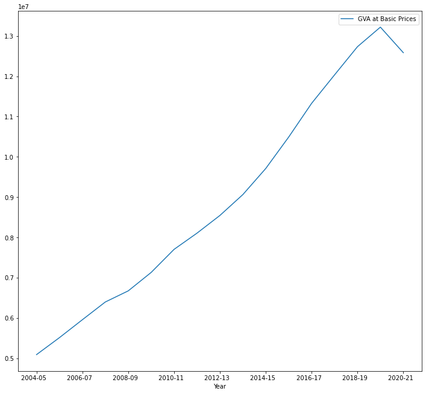

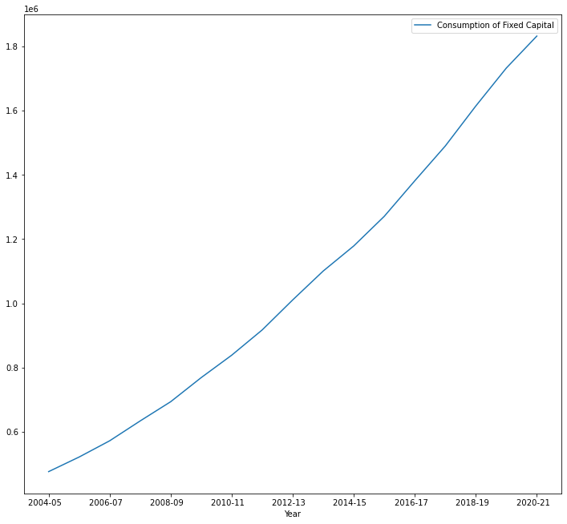

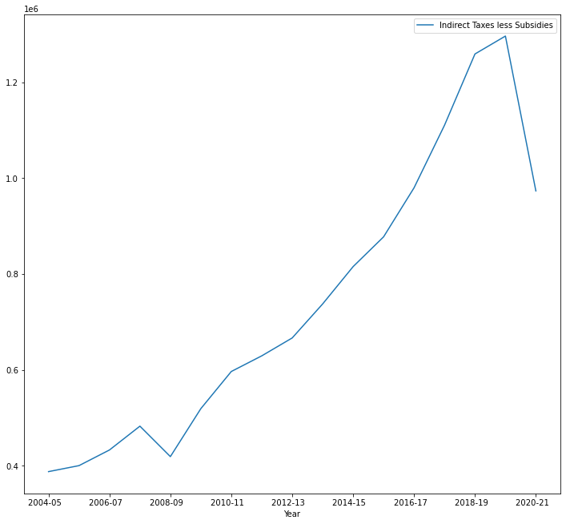

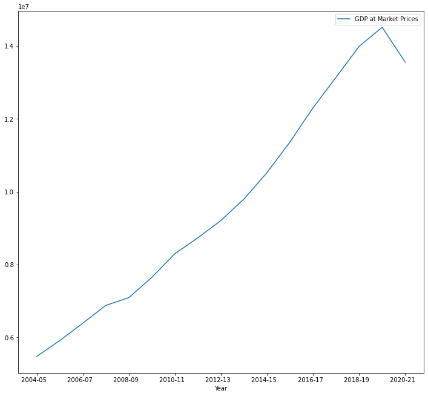

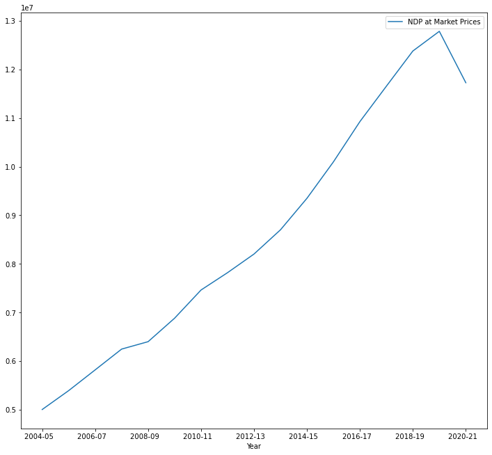

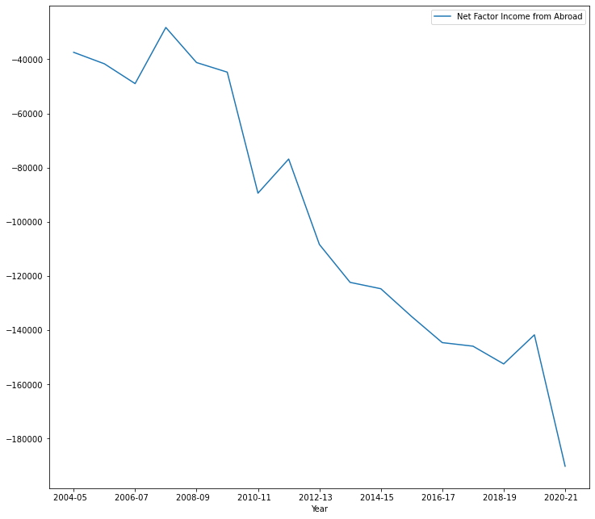

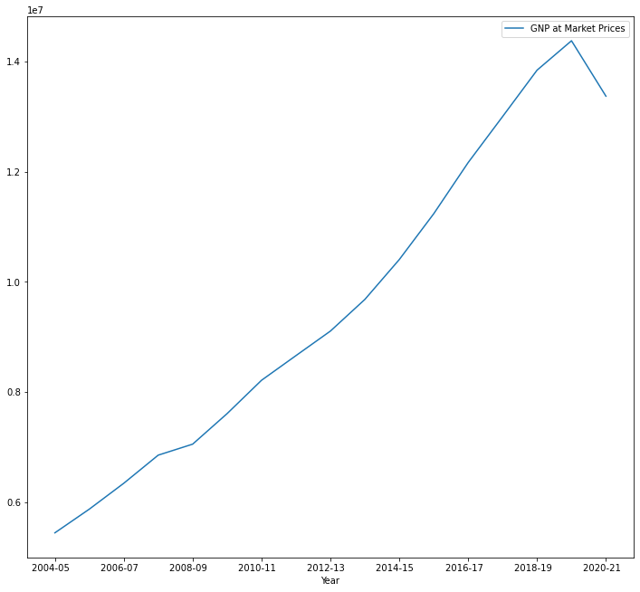

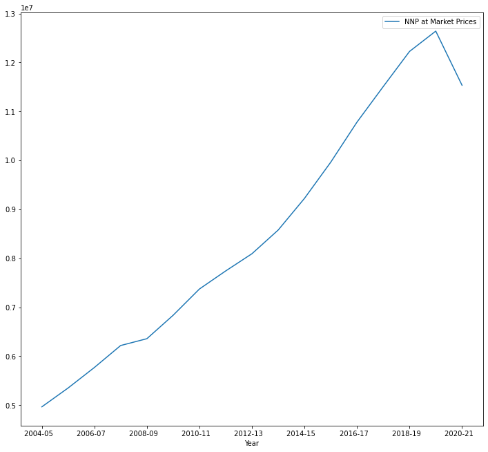

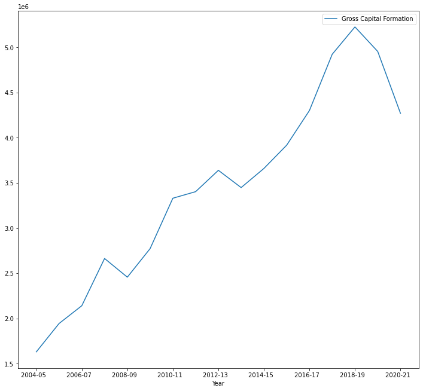

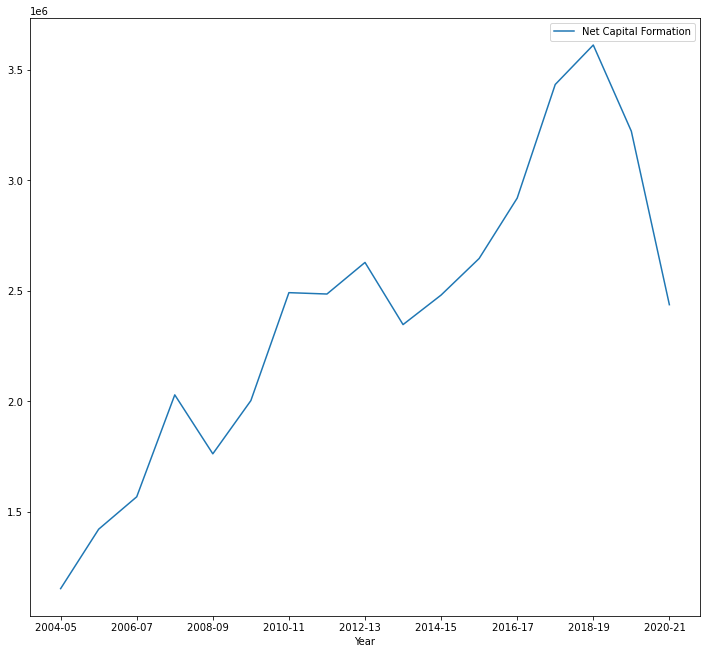

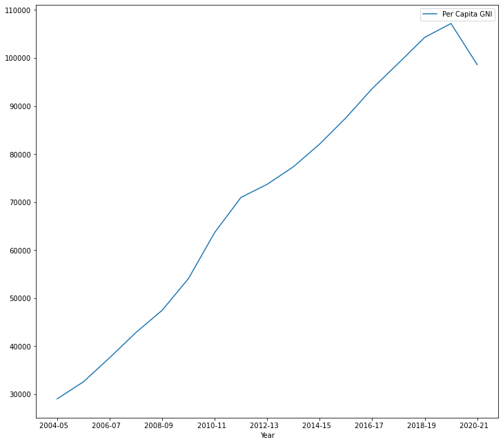

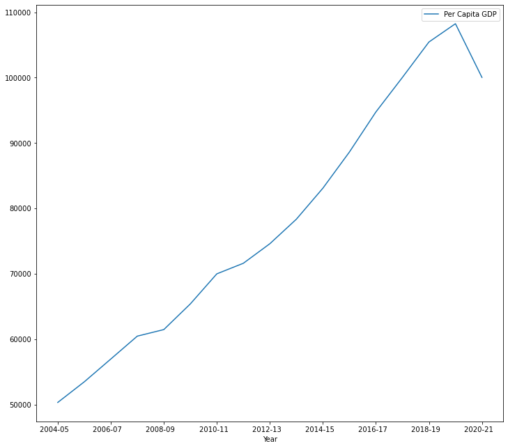

[2 more figures not shown]

```python
for col in df_2.drop('Year', axis = 1).columns:
    df_2.plot(x='Year', y = col, kind = 'line', figsize = (12,11))
    plt.show
```

- From theory, we know that GVA at Basic Prices, GDP at Market Prices, NDP at Market Prices, GNP at Market Prices and NNP at Market Prices should move together. Let us plot them together to see if it is true for the data.

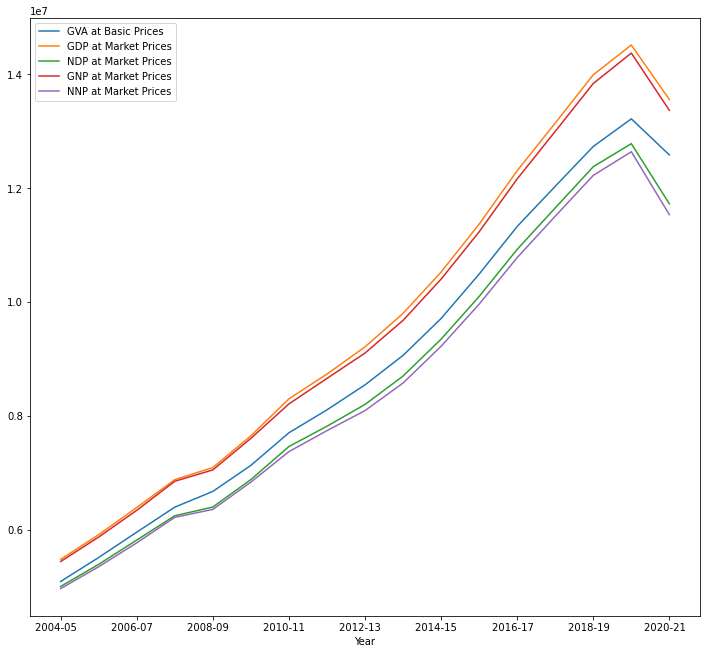

```python
df_2.plot(x = 'Year', y = ['GVA at Basic Prices', 'GDP at Market Prices', 'NDP at Market Prices', 'GNP at Market Prices', 'NNP at Market Prices'], kind = 'line', figsize = (12,11))
```

- We see that the graphs almost move together. We also see that the absolute difference between GNP and GDP or Net Factor Income from Abroad (NFIA) has been increasing over the years. Let us now plot a heatmap of correlation co-efficients between different macroeconomic aggregates.

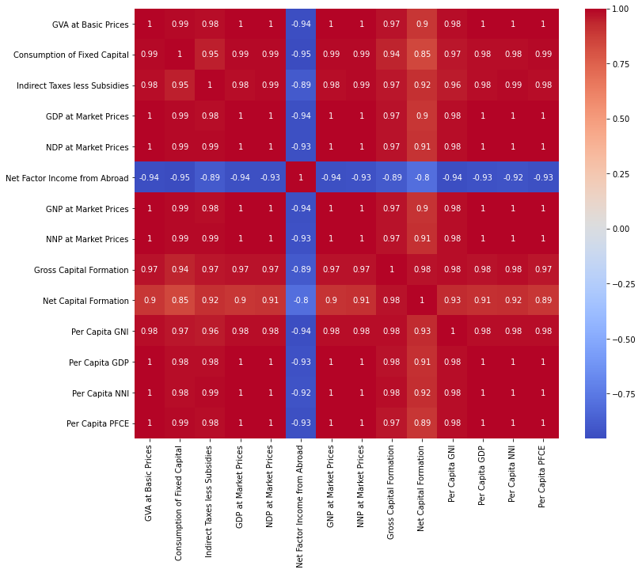

```python
plt.figure(figsize=(12,10))
sns.heatmap(df_2.drop('Year', axis=1).corr(), cmap='coolwarm',annot=True)
plt.show()
```

- We see how most of the values are perfectly correlated with each other. This is backed up by theory. Let us now create another dataframe which will calculate percentage change over the years in each of the variable.

```python
df_3 = df_2.drop('Year', axis = 1).pct_change().mul(100)
df_3
```

|  | GVA at Basic Prices | Consumption of Fixed Capital | Indirect Taxes less Subsidies | GDP at Market Prices | NDP at Market Prices | Net Factor Income from Abroad | GNP at Market Prices | NNP at Market Prices | Gross Capital Formation | Net Capital Formation | Per Capita GNI | Per Capita GDP | Per Capita NNI | Per Capita PFCE |
| --- | --- | --- | --- | --- | --- | --- | --- | --- | --- | --- | --- | --- | --- | --- |
| 0 | NaN | NaN | NaN | NaN | NaN | NaN | NaN | NaN | NaN | NaN | NaN | NaN | NaN | NaN |
| 1 | 8.28129 | 9.55431 | 3.22499 | 7.92343 | 7.76836 | 11.31350 | 7.90011 | 7.74164 | 19.27474 | 23.28293 | 12.21863 | 6.26528 | 6.08625 | 5.80517 |
| 2 | 8.05442 | 9.68921 | 8.14764 | 8.06073 | 7.90332 | 17.53443 | 7.99350 | 7.82830 | 10.13386 | 10.29680 | 15.39688 | 6.51857 | 6.29095 | 3.43673 |
| 3 | 7.38337 | 10.81663 | 11.47877 | 7.66082 | 7.35074 | -42.29576 | 8.04667 | 7.77220 | 24.40823 | 29.36114 | 13.93260 | 6.14774 | 6.25693 | 5.77285 |
| 4 | 4.31240 | 9.44838 | -13.15981 | 3.08670 | 2.44141 | 45.79545 | 2.91053 | 2.24437 | -7.75629 | -13.12707 | 10.80577 | 1.65713 | 0.82710 | 3.00425 |
| 5 | 6.85655 | 10.82176 | 23.86853 | 7.86188 | 7.54114 | 8.60672 | 7.85753 | 7.53423 | 12.84371 | 13.63893 | 13.87637 | 6.38706 | 6.06341 | 3.56729 |
| 6 | 8.02988 | 9.08547 | 14.92156 | 8.49759 | 8.43194 | 99.77882 | 7.96045 | 7.83397 | 20.12197 | 24.35494 | 17.73558 | 7.03428 | 6.37897 | 5.27998 |
| 7 | 5.22333 | 9.39169 | 5.47353 | 5.24131 | 4.77503 | -14.08537 | 5.45176 | 5.00375 | 2.17881 | -0.24794 | 11.45936 | 2.30770 | 2.07772 | 4.42770 |
| 8 | 5.41917 | 10.19284 | 5.93575 | 5.45639 | 4.90081 | 41.04247 | 5.14068 | 4.54219 | 6.94351 | 5.74464 | 3.86367 | 4.17554 | 3.27245 | 4.18983 |
| 9 | 6.05379 | 8.90000 | 10.64579 | 6.38611 | 6.07636 | 12.90984 | 6.30847 | 5.98488 | -5.24993 | -10.69031 | 4.94881 | 5.02545 | 4.62936 | 5.93079 |
| 10 | 7.15478 | 7.09010 | 10.54867 | 7.41023 | 7.45072 | 1.91567 | 7.47968 | 7.52966 | 6.13436 | 5.68628 | 6.12240 | 6.05382 | 6.17175 | 5.05030 |
| 11 | 8.02849 | 7.82646 | 7.61237 | 7.99625 | 8.01766 | 8.20902 | 7.99370 | 8.01507 | 7.03858 | 6.66430 | 6.64694 | 6.64946 | 6.66804 | 6.58216 |
| 12 | 7.97202 | 8.70539 | 11.65489 | 8.25631 | 8.19979 | 7.15419 | 8.26954 | 8.21395 | 9.79028 | 10.31128 | 6.93597 | 6.92289 | 6.88106 | 6.79827 |
| 13 | 6.23118 | 7.84599 | 13.31787 | 6.79538 | 6.66255 | 0.90814 | 6.86536 | 6.73971 | 14.46432 | 17.59632 | 5.64543 | 5.57626 | 5.52122 | 5.02604 |
| 14 | 5.81367 | 8.35845 | 13.39180 | 6.45385 | 6.21037 | 4.49153 | 6.47588 | 6.23216 | 6.15503 | 5.19876 | 5.43278 | 5.41097 | 5.19145 | 6.04044 |
| 15 | 3.81408 | 7.31920 | 2.96763 | 3.73792 | 3.27083 | -7.04263 | 3.85666 | 3.39943 | -5.19355 | -10.78710 | 2.77240 | 2.65490 | 2.31994 | 4.11479 |
| 16 | -4.79899 | 5.75167 | -24.91992 | -6.59608 | -8.26966 | 34.21932 | -6.99845 | -8.74594 | -13.81875 | -24.34285 | -7.98767 | -7.58958 | -9.71657 | -7.00449 |

```python
first_column = df_2['Year']
first_column
```

```
0     2004-05
1     2005-06
2     2006-07
3     2007-08
4     2008-09
5     2009-10
6     2010-11
7     2011-12
8     2012-13
9     2013-14
10    2014-15
11    2015-16
12    2016-17
13    2017-18
14    2018-19
15    2019-20
16    2020-21
Name: Year, dtype: object
```

```python
df_3.insert(0, 'Year', first_column) # This will insert 'Year' as the first column in the new dataframe.
```

```python
df_3
```

|  | Year | GVA at Basic Prices | Consumption of Fixed Capital | Indirect Taxes less Subsidies | GDP at Market Prices | NDP at Market Prices | Net Factor Income from Abroad | GNP at Market Prices | NNP at Market Prices | Gross Capital Formation | Net Capital Formation | Per Capita GNI | Per Capita GDP | Per Capita NNI | Per Capita PFCE |
| --- | --- | --- | --- | --- | --- | --- | --- | --- | --- | --- | --- | --- | --- | --- | --- |
| 0 | 2004-05 | NaN | NaN | NaN | NaN | NaN | NaN | NaN | NaN | NaN | NaN | NaN | NaN | NaN | NaN |
| 1 | 2005-06 | 8.28129 | 9.55431 | 3.22499 | 7.92343 | 7.76836 | 11.31350 | 7.90011 | 7.74164 | 19.27474 | 23.28293 | 12.21863 | 6.26528 | 6.08625 | 5.80517 |
| 2 | 2006-07 | 8.05442 | 9.68921 | 8.14764 | 8.06073 | 7.90332 | 17.53443 | 7.99350 | 7.82830 | 10.13386 | 10.29680 | 15.39688 | 6.51857 | 6.29095 | 3.43673 |
| 3 | 2007-08 | 7.38337 | 10.81663 | 11.47877 | 7.66082 | 7.35074 | -42.29576 | 8.04667 | 7.77220 | 24.40823 | 29.36114 | 13.93260 | 6.14774 | 6.25693 | 5.77285 |
| 4 | 2008-09 | 4.31240 | 9.44838 | -13.15981 | 3.08670 | 2.44141 | 45.79545 | 2.91053 | 2.24437 | -7.75629 | -13.12707 | 10.80577 | 1.65713 | 0.82710 | 3.00425 |
| 5 | 2009-10 | 6.85655 | 10.82176 | 23.86853 | 7.86188 | 7.54114 | 8.60672 | 7.85753 | 7.53423 | 12.84371 | 13.63893 | 13.87637 | 6.38706 | 6.06341 | 3.56729 |
| 6 | 2010-11 | 8.02988 | 9.08547 | 14.92156 | 8.49759 | 8.43194 | 99.77882 | 7.96045 | 7.83397 | 20.12197 | 24.35494 | 17.73558 | 7.03428 | 6.37897 | 5.27998 |
| 7 | 2011-12 | 5.22333 | 9.39169 | 5.47353 | 5.24131 | 4.77503 | -14.08537 | 5.45176 | 5.00375 | 2.17881 | -0.24794 | 11.45936 | 2.30770 | 2.07772 | 4.42770 |
| 8 | 2012-13 | 5.41917 | 10.19284 | 5.93575 | 5.45639 | 4.90081 | 41.04247 | 5.14068 | 4.54219 | 6.94351 | 5.74464 | 3.86367 | 4.17554 | 3.27245 | 4.18983 |
| 9 | 2013-14 | 6.05379 | 8.90000 | 10.64579 | 6.38611 | 6.07636 | 12.90984 | 6.30847 | 5.98488 | -5.24993 | -10.69031 | 4.94881 | 5.02545 | 4.62936 | 5.93079 |
| 10 | 2014-15 | 7.15478 | 7.09010 | 10.54867 | 7.41023 | 7.45072 | 1.91567 | 7.47968 | 7.52966 | 6.13436 | 5.68628 | 6.12240 | 6.05382 | 6.17175 | 5.05030 |
| 11 | 2015-16 | 8.02849 | 7.82646 | 7.61237 | 7.99625 | 8.01766 | 8.20902 | 7.99370 | 8.01507 | 7.03858 | 6.66430 | 6.64694 | 6.64946 | 6.66804 | 6.58216 |
| 12 | 2016-17 | 7.97202 | 8.70539 | 11.65489 | 8.25631 | 8.19979 | 7.15419 | 8.26954 | 8.21395 | 9.79028 | 10.31128 | 6.93597 | 6.92289 | 6.88106 | 6.79827 |
| 13 | 2017-18 | 6.23118 | 7.84599 | 13.31787 | 6.79538 | 6.66255 | 0.90814 | 6.86536 | 6.73971 | 14.46432 | 17.59632 | 5.64543 | 5.57626 | 5.52122 | 5.02604 |
| 14 | 2018-19 | 5.81367 | 8.35845 | 13.39180 | 6.45385 | 6.21037 | 4.49153 | 6.47588 | 6.23216 | 6.15503 | 5.19876 | 5.43278 | 5.41097 | 5.19145 | 6.04044 |
| 15 | 2019-20 | 3.81408 | 7.31920 | 2.96763 | 3.73792 | 3.27083 | -7.04263 | 3.85666 | 3.39943 | -5.19355 | -10.78710 | 2.77240 | 2.65490 | 2.31994 | 4.11479 |
| 16 | 2020-21 | -4.79899 | 5.75167 | -24.91992 | -6.59608 | -8.26966 | 34.21932 | -6.99845 | -8.74594 | -13.81875 | -24.34285 | -7.98767 | -7.58958 | -9.71657 | -7.00449 |

- Let us plot growth in GDP at Market Prices

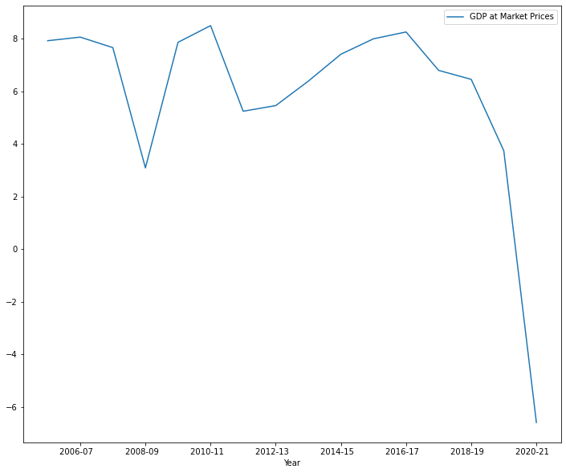

```python
df_3.plot('Year', 'GDP at Market Prices', kind = 'line', figsize = (12,10))
```

- We are able to see a sharp decline in growth in 2008-09 due to the Global Financial Crisis and in 2020-21 due to the after effects of Global Coronavirus Pandemic. This completes our exploratory analysis of data on different macro economic aggregates.